# Size symbolism in production and perception

# 5. Exploratory data analysis

## 5.1 Sample sizes

```r
cat("Vowel rows:        ", nrow(vowel_long), "\n")
```

```
## Vowel rows:         1361
```

```r
cat("Fricative rows:    ", nrow(fric_long),  "\n")
```

```
## Fricative rows:     2471
```

```r
cat("Perception rows:   ", nrow(perc),       "\n")
```

```
## Perception rows:    936
```

```r
cat("Speakers:          ", n_distinct(perc$speaker),   "\n")
```

```
## Speakers:           39
```

```r
cat("Listeners:         ", n_distinct(perc$listener),  "\n")
```

```
## Listeners:          39
```

```r
cat("Items:             ", n_distinct(perc$item_english), "\n")
```

```
## Items:              36
```

```r
perc |> tabyl(animacy, size, category) |> print()
```

```
## $appliance
##    animacy big small
##    animate   0     0
##  inanimate  78    78
##
## $bird
##    animacy big small
##    animate  78    78
##  inanimate   0     0
##
## $instrument
##    animacy big small
##    animate   0     0
##  inanimate  78    78
##
## $mammal
##    animacy big small
##    animate  78    78
##  inanimate   0     0
##
## $reptile
##    animacy big small
##    animate  78    78
##  inanimate   0     0
##
## $vehicle
##    animacy big small
##    animate   0     0
##  inanimate  78    78
```

## 5.2 Distributions of acoustic features

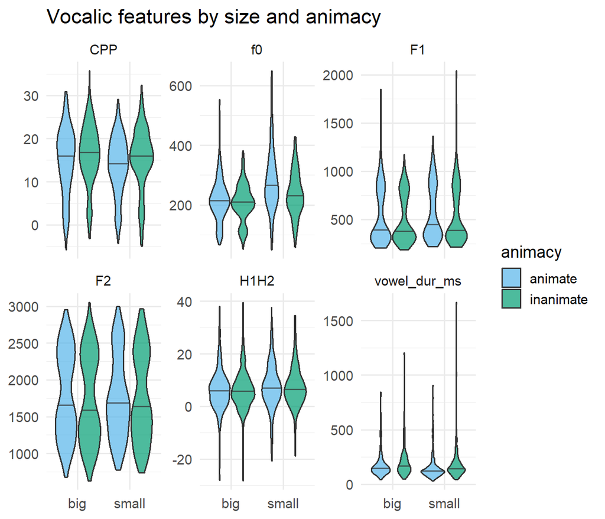

**Figure 4.** Vocalic features by size and animacy. Median lines inside violins.

```r
acoustic_long <- vowel_long |>
  select(speaker, item_english, vowel, size, animacy,
         vowel_dur_ms, f0, F1, F2, CPP, H1H2) |>
  pivot_longer(c(vowel_dur_ms, f0, F1, F2, CPP, H1H2),
               names_to = "feature", values_to = "value")

ggplot(acoustic_long, aes(x = size, y = value, fill = animacy)) +
  geom_violin(draw_quantiles = 0.5, alpha = 0.7) +
  facet_wrap(~ feature, scales = "free_y") +
  scale_fill_manual(values = colorBlindBlack8[c(3, 4)]) +
  labs(title = "Vocalic features by size and animacy",
       x = NULL, y = NULL)
```

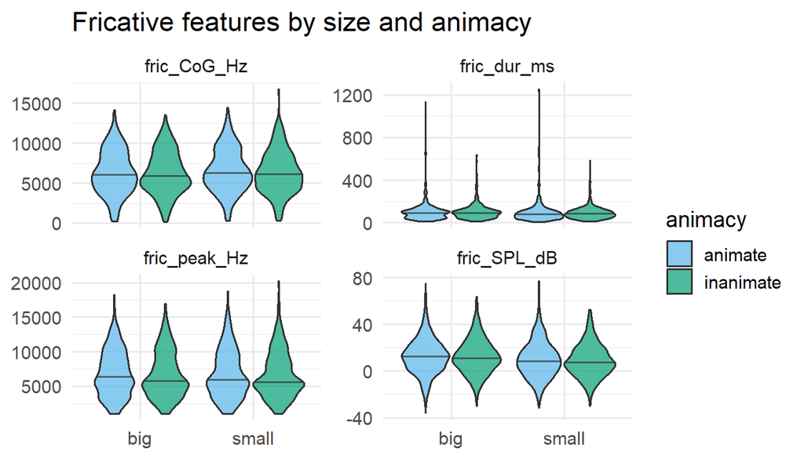

**Figure 5.** Fricative features by size and animacy.

```r
fric_long |>
  pivot_longer(c(fric_dur_ms, fric_SPL_dB, fric_peak_Hz, fric_CoG_Hz),
               names_to = "feature", values_to = "value") |>
  ggplot(aes(x = size, y = value, fill = animacy)) +
  geom_violin(draw_quantiles = 0.5, alpha = 0.7) +
  facet_wrap(~ feature, scales = "free_y") +
  scale_fill_manual(values = colorBlindBlack8[c(3, 4)]) +
  labs(title = "Fricative features by size and animacy",
       x = NULL, y = NULL)
```

## 5.3 Outlier flags (vowel duration)

```r
vowel_long |>
  group_by(vowel) |>
  mutate(z = scale(log(vowel_dur_ms))[, 1]) |>
  ungroup() |>
  filter(abs(z) > 3) |>
  select(file_key, vowel, vowel_dur_ms, z, size, animacy) |>
  arrange(desc(abs(z)))
```

| file_key | vowel | vowel_dur_ms | z | size | animacy |
| --- | --- | --- | --- | --- | --- |
| h2_10_jumbojet_m34 | a: | 1203.659 | 4.288114 | big | inanimate |
| c2_11_kleinerbagger_w20 | i: | 1666.277 | 4.268902 | small | inanimate |
| c2_11_kleinerbagger_w20 | a: | 1009.379 | 3.914414 | small | inanimate |
| h2_07_schildkorete_m34 | u: | 792.521 | 3.582313 | small | animate |
| h2_07_schildkorete_m34 | i: | 905.738 | 3.245476 | small | animate |
| c3_12_anakonda_w31 | i: | 843.682 | 3.126320 | big | animate |

Extreme productions are retained: speaker verification confirmed these are genuine iconic productions (not measurement errors). Trimming would discard signal. The lognormal family on duration accommodates the right tail; PPCs are the diagnostic that matters.

## 5.4 Perception accuracy snapshot

```r
perc |>
  summarise(
    size_acc      = mean(size_correct),
    animacy_acc   = mean(animacy_correct),
    category_acc  = mean(category_correct),
    item_acc      = mean(item_correct)
  )
```

| size_acc | animacy_acc | category_acc | item_acc |
| --- | --- | --- | --- |
| 0.7521368 | 0.7179487 | 0.409188 | 0.2532051 |

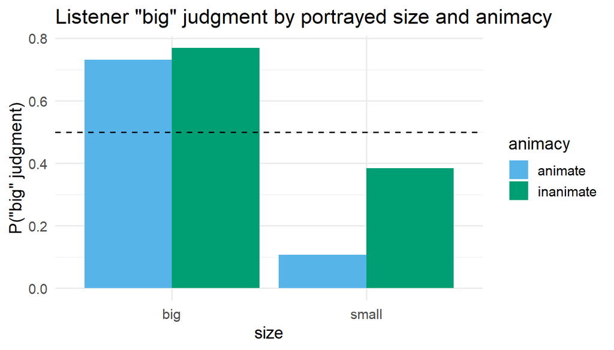

**Figure 6.** Proportion of ‘big’ judgments by portrayed size and animacy of the referent.

```r
perc |>
  group_by(animacy, size) |>
  summarise(prop_big_judgment = mean(big_judgment), .groups = "drop") |>
  ggplot(aes(x = size, y = prop_big_judgment, fill = animacy)) +
  geom_col(position = position_dodge()) +
  geom_hline(yintercept = 0.5, linetype = 2) +
  scale_fill_manual(values = colorBlindBlack8[c(3, 4)]) +
  labs(y = "P(\"big\" judgment)",
       title = "Listener \"big\" judgment by portrayed size and animacy")
```

# 6. Primary analyses – duration and f0

The primary models test our expectations directly: size and animacy should each leave a trace on vowel duration and f0, in both production and perception. Each fit includes `size_c`, `animacy_c`, and their interaction so that a single posterior can answer three questions at once: (i) is there a size effect in the expected direction, (ii) does animacy shift the outcome independent of size, and (iii) does animacy modulate the size effect? Fitting all three together avoids the multiple-testing pitfalls of separate models. For size the predicted direction is fixed in advance (longer for big, lower f0 for big); for animacy we keep direction and channel (interaction vs. main effect) open.

## 6.1 A reusable fitter

```r
default_priors <- function(family = "gaussian") {
  switch(family,
    gaussian  = c(prior(normal(0, 100),        class = "b"),
                  prior(student_t(3, 0, 100),  class = "Intercept"),
                  prior(student_t(3, 0, 100),  class = "sd"),
                  prior(student_t(3, 0, 100),  class = "sigma")),
    lognormal = c(prior(normal(0, 1.5),        class = "b"),
                  prior(student_t(3, 5, 5),    class = "Intercept"),
                  prior(student_t(3, 0, 2),    class = "sd"),
                  prior(student_t(3, 0, 2),    class = "sigma")),
    bernoulli = c(prior(normal(0, 5),          class = "b"),
                  prior(student_t(3, 0, 10),   class = "Intercept"),
                  prior(student_t(3, 0, 5),    class = "sd"))
  )
}

fit_brm <- function(formula, data, family = gaussian(), file = NULL,
                    priors = NULL, ...) {
  fam_name <- family$family
  if (is.null(priors)) priors <- default_priors(fam_name)
  # Inform the user whether we're hitting the cache or rebuilding
  if (!is.null(file)) {
    rds <- if (endsWith(file, ".rds")) file else paste0(file, ".rds")
    if (file.exists(rds)) {
      message("[fit_brm] Cache exists at '", basename(rds),
              "' – brms will reuse it if formula/data/prior match.")
    } else {
      message("[fit_brm] No cache at '", basename(rds), "' – fitting from scratch.")
    }
  }
  brm(formula = formula, data = data, family = family,
      prior = priors,
      chains = 4, iter = 8000, warmup = 4000, cores = 4,
      control = list(adapt_delta = 0.95, max_treedepth = 12),
      seed   = 2137,
      file   = file,
      refresh = 100,
      ...)
}
```

## 6.2 Production: vowel duration

```r
m_vdur <- fit_brm(
  bf(vowel_dur_ms ~ size_c * animacy_c + vowel +
       (1 + size_c | speaker) + (1 | item_english)),
  data   = vowel_long |> filter(!is.na(vowel_dur_ms)),
  family = lognormal(),
  file   = paste0(models, "m_vdur")
)
```

```
## [fit_brm] Cache exists at 'm_vdur.rds' – brms will reuse it if formula/data/prior match.
```

```r
summary(m_vdur)
```

```
##  Family: lognormal
##   Links: mu = identity
## Formula: vowel_dur_ms ~ size_c * animacy_c + vowel + (1 + size_c | speaker) + (1 | item_english)
##    Data: data (Number of observations: 1360)
##   Draws: 4 chains, each with iter = 8000; warmup = 4000; thin = 1;
##          total post-warmup draws = 16000
##
## Multilevel Hyperparameters:
## ~item_english (Number of levels: 36)
##               Estimate Est.Error l-95% CI u-95% CI Rhat Bulk_ESS Tail_ESS
## sd(Intercept)     0.19      0.03     0.14     0.25 1.00     4018     6726
##
## ~speaker (Number of levels: 42)
##                       Estimate Est.Error l-95% CI u-95% CI Rhat Bulk_ESS
## sd(Intercept)             0.31      0.04     0.24     0.39 1.00     2833
## sd(size_c)                0.17      0.03     0.12     0.24 1.00     5995
## cor(Intercept,size_c)     0.37      0.18    -0.01     0.69 1.00     6858
##                       Tail_ESS
## sd(Intercept)             4618
## sd(size_c)                8506
## cor(Intercept,size_c)     9615
##
## Regression Coefficients:
##                  Estimate Est.Error l-95% CI u-95% CI Rhat Bulk_ESS Tail_ESS
## Intercept            5.07      0.06     4.95     5.19 1.00     1623     3136
## size_c               0.16      0.07     0.02     0.30 1.00     3379     6514
## animacy_c           -0.15      0.07    -0.28    -0.02 1.00     3496     5896
## voweli:             -0.20      0.02    -0.25    -0.16 1.00    18845    12148
## vowelu:              0.05      0.02     0.00     0.09 1.00    18256    12754
## size_c:animacy_c     0.04      0.13    -0.22     0.30 1.00     3452     5869
##
## Further Distributional Parameters:
##       Estimate Est.Error l-95% CI u-95% CI Rhat Bulk_ESS Tail_ESS
## sigma     0.35      0.01     0.34     0.37 1.00    20196    11979
##
## Draws were sampled using sample(hmc). For each parameter, Bulk_ESS
## and Tail_ESS are effective sample size measures, and Rhat is the potential
## scale reduction factor on split chains (at convergence, Rhat = 1).
```

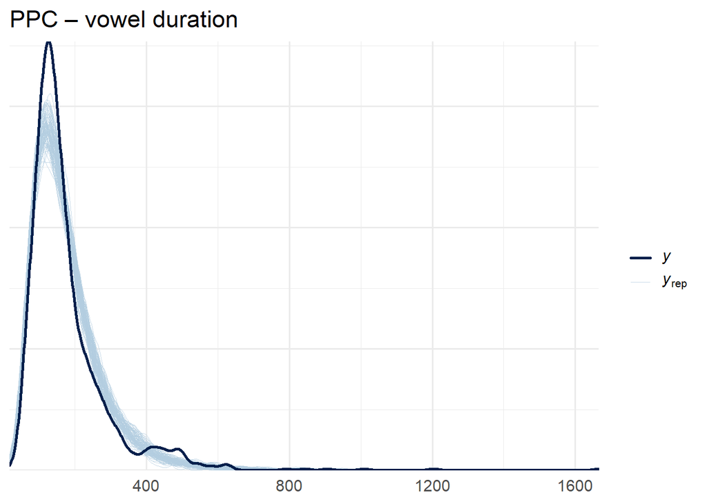

**Figure 7.** Posterior predictive check for vowel duration (lognormal).

```r
pp_check(m_vdur, ndraws = 100) + ggtitle("PPC – vowel duration")
```

## 6.3 Production: f0

f0 is modelled with `lognormal()` because it is strictly positive and right-skewed, especially once male and female speakers are pooled. The covariate `sex` is included because male and female speakers differ by roughly 80–100 Hz on average; without `sex` the random intercept absorbs that difference but the fixed-effect intercept becomes harder to interpret. The lognormal choice has a pleasant analytical side-effect: with the sum-coded `size_c` predictor (`-0.5` for small, `+0.5` for big), the coefficient is exactly `log(f0_big / f0_small)`, so `exp(β)` is the multiplicative ratio of speaker f0 for big versus small productions – a clean quantity for the frequency-code prediction, which itself is a *ratio* claim (lower f0 indexes larger body size across vertebrates) rather than a Hz claim. The prediction – lower f0 for big referents – is the central frequency-code expectation (Ohala 1984, 1983).

```r
m_f0 <- fit_brm(
  bf(f0 ~ size_c * animacy_c + sex + vowel +
       (1 + size_c | speaker) + (1 | item_english)),
  data   = vowel_long |> filter(!is.na(f0)),
  family = lognormal(),
  file   = paste0(models, "m_f0")
)
```

```
## [fit_brm] Cache exists at 'm_f0.rds' – brms will reuse it if formula/data/prior match.
```

```r
summary(m_f0)
```

```
##  Family: lognormal
##   Links: mu = identity
## Formula: f0 ~ size_c * animacy_c + sex + vowel + (1 + size_c | speaker) + (1 | item_english)
##    Data: data (Number of observations: 1351)
##   Draws: 4 chains, each with iter = 8000; warmup = 4000; thin = 1;
##          total post-warmup draws = 16000
##
## Multilevel Hyperparameters:
## ~item_english (Number of levels: 36)
##               Estimate Est.Error l-95% CI u-95% CI Rhat Bulk_ESS Tail_ESS
## sd(Intercept)     0.14      0.02     0.11     0.19 1.00     3474     6943
##
## ~speaker (Number of levels: 42)
##                       Estimate Est.Error l-95% CI u-95% CI Rhat Bulk_ESS
## sd(Intercept)             0.11      0.02     0.09     0.15 1.00     3681
## sd(size_c)                0.07      0.02     0.03     0.11 1.00     5584
## cor(Intercept,size_c)    -0.53      0.24    -0.94     0.02 1.00     4164
##                       Tail_ESS
## sd(Intercept)             6872
## sd(size_c)                5843
## cor(Intercept,size_c)     4405
##
## Regression Coefficients:
##                  Estimate Est.Error l-95% CI u-95% CI Rhat Bulk_ESS Tail_ESS
## Intercept            4.80      0.05     4.70     4.90 1.00     3088     5310
## size_c              -0.18      0.05    -0.28    -0.08 1.00     2835     4618
## animacy_c            0.10      0.05     0.00     0.20 1.00     2786     4780
## sexw                 0.58      0.05     0.49     0.68 1.00     3010     5217
## voweli:              0.14      0.01     0.11     0.17 1.00    15887    12232
## vowelu:              0.21      0.01     0.18     0.24 1.00    15778    13209
## size_c:animacy_c    -0.11      0.10    -0.30     0.08 1.00     2636     4726
##
## Further Distributional Parameters:
##       Estimate Est.Error l-95% CI u-95% CI Rhat Bulk_ESS Tail_ESS
## sigma     0.22      0.00     0.21     0.23 1.00    17705    11693
##
## Draws were sampled using sample(hmc). For each parameter, Bulk_ESS
## and Tail_ESS are effective sample size measures, and Rhat is the potential
## scale reduction factor on split chains (at convergence, Rhat = 1).
```

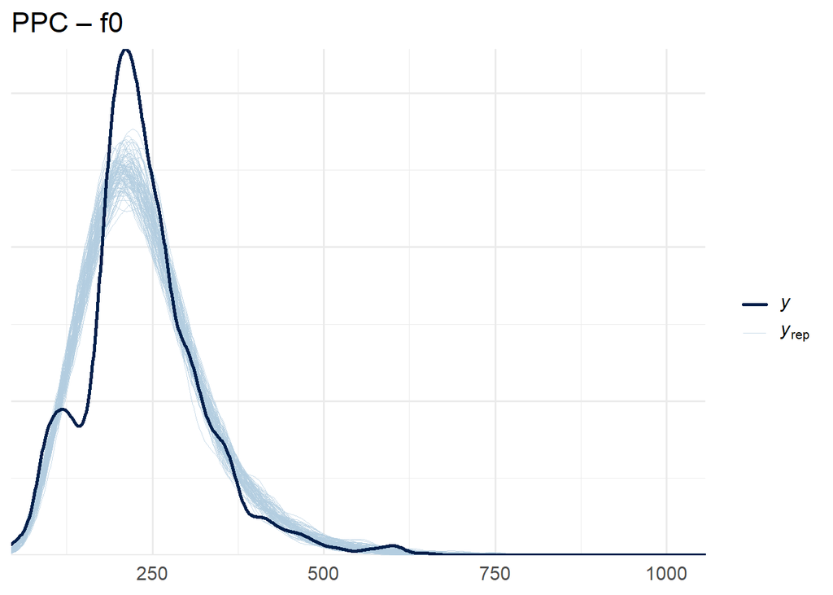

**Figure 8.** Posterior predictive check for f0 (lognormal, with sex covariate).

```r
pp_check(m_f0, ndraws = 100) + ggtitle("PPC – f0")
```

## 6.4 Perception: vowel duration → “big” judgment

```r
m_perc_dur <- fit_brm(
  bf(big_judgment ~ vowel_dur_ms_mean_z * animacy_c +
       (1 | listener) + (1 | speaker) + (1 | item_english)),
  data   = perc |> filter(!is.na(vowel_dur_ms_mean_z)),
  family = bernoulli(),
  file   = paste0(models, "m_perc_dur")
)
```

```
## [fit_brm] Cache exists at 'm_perc_dur.rds' – brms will reuse it if formula/data/prior match.
```

```r
summary(m_perc_dur)
```

```
##  Family: bernoulli
##   Links: mu = logit
## Formula: big_judgment ~ vowel_dur_ms_mean_z * animacy_c + (1 | listener) + (1 | speaker) + (1 | item_english)
##    Data: data (Number of observations: 916)
##   Draws: 4 chains, each with iter = 8000; warmup = 4000; thin = 1;
##          total post-warmup draws = 16000
##
## Multilevel Hyperparameters:
## ~item_english (Number of levels: 36)
##               Estimate Est.Error l-95% CI u-95% CI Rhat Bulk_ESS Tail_ESS
## sd(Intercept)     1.81      0.28     1.34     2.43 1.00     4390     8026
##
## ~listener (Number of levels: 39)
##               Estimate Est.Error l-95% CI u-95% CI Rhat Bulk_ESS Tail_ESS
## sd(Intercept)     0.11      0.08     0.00     0.29 1.00    10629     8554
##
## ~speaker (Number of levels: 39)
##               Estimate Est.Error l-95% CI u-95% CI Rhat Bulk_ESS Tail_ESS
## sd(Intercept)     0.13      0.10     0.00     0.35 1.00     7735     7106
##
## Regression Coefficients:
##                               Estimate Est.Error l-95% CI u-95% CI Rhat
## Intercept                        -0.08      0.32    -0.72     0.54 1.00
## vowel_dur_ms_mean_z               0.05      0.10    -0.15     0.25 1.00
## animacy_c                        -0.93      0.64    -2.21     0.33 1.00
## vowel_dur_ms_mean_z:animacy_c     0.34      0.20    -0.05     0.73 1.00
##                               Bulk_ESS Tail_ESS
## Intercept                         2724     5482
## vowel_dur_ms_mean_z              22841    13039
## animacy_c                         2952     4869
## vowel_dur_ms_mean_z:animacy_c    19535    12972
##
## Draws were sampled using sample(hmc). For each parameter, Bulk_ESS
## and Tail_ESS are effective sample size measures, and Rhat is the potential
## scale reduction factor on split chains (at convergence, Rhat = 1).
```

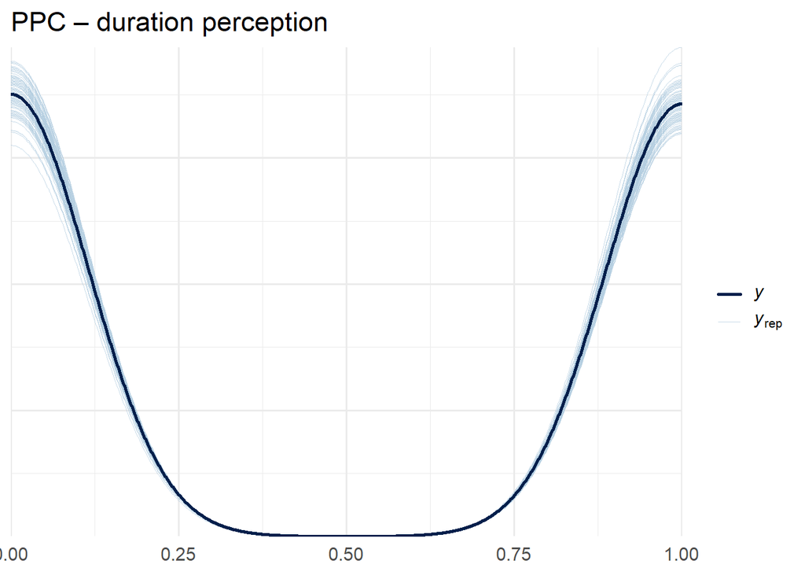

**Figure 9.** Posterior predictive check for perception of duration (Bernoulli).

```r
pp_check(m_perc_dur, ndraws = 100) + ggtitle("PPC – duration perception")
```

## 6.5 Perception: f0 → “big” judgment

```r
m_perc_f0 <- fit_brm(
  bf(big_judgment ~ f0_mean_z * animacy_c +
       (1 | listener) + (1 | speaker) + (1 | item_english)),
  data   = perc |> filter(!is.na(f0_mean_z)),
  family = bernoulli(),
  file   = paste0(models, "m_perc_f0")
)
```

```
## [fit_brm] Cache exists at 'm_perc_f0.rds' – brms will reuse it if formula/data/prior match.
```

```r
summary(m_perc_f0)
```

```
##  Family: bernoulli
##   Links: mu = logit
## Formula: big_judgment ~ f0_mean_z * animacy_c + (1 | listener) + (1 | speaker) + (1 | item_english)
##    Data: data (Number of observations: 916)
##   Draws: 4 chains, each with iter = 8000; warmup = 4000; thin = 1;
##          total post-warmup draws = 16000
##
## Multilevel Hyperparameters:
## ~item_english (Number of levels: 36)
##               Estimate Est.Error l-95% CI u-95% CI Rhat Bulk_ESS Tail_ESS
## sd(Intercept)     1.52      0.25     1.09     2.08 1.00     6079     9506
##
## ~listener (Number of levels: 39)
##               Estimate Est.Error l-95% CI u-95% CI Rhat Bulk_ESS Tail_ESS
## sd(Intercept)     0.10      0.08     0.00     0.30 1.00    10356     9898
##
## ~speaker (Number of levels: 39)
##               Estimate Est.Error l-95% CI u-95% CI Rhat Bulk_ESS Tail_ESS
## sd(Intercept)     0.13      0.10     0.01     0.36 1.00     9342     8318
##
## Regression Coefficients:
##                     Estimate Est.Error l-95% CI u-95% CI Rhat Bulk_ESS Tail_ESS
## Intercept              -0.09      0.28    -0.63     0.46 1.00     4850     8147
## f0_mean_z              -0.51      0.13    -0.77    -0.25 1.00    21413    13170
## animacy_c              -0.71      0.55    -1.81     0.35 1.00     5253     8631
## f0_mean_z:animacy_c    -0.28      0.26    -0.79     0.22 1.00    27729    13337
##
## Draws were sampled using sample(hmc). For each parameter, Bulk_ESS
## and Tail_ESS are effective sample size measures, and Rhat is the potential
## scale reduction factor on split chains (at convergence, Rhat = 1).
```

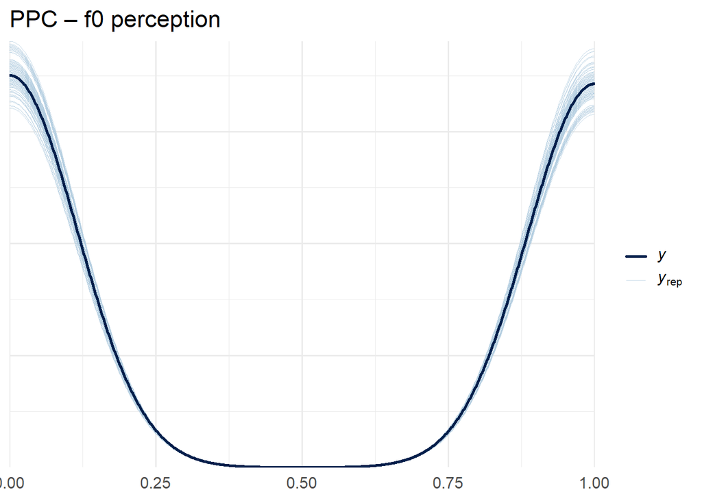

**Figure 10.** Posterior predictive check for perception of f0 (Bernoulli).

```r
pp_check(m_perc_f0, ndraws = 100) + ggtitle("PPC – f0 perception")
```

## 6.6 Reporting helpers

Two small helpers do the heavy lifting for everything that follows. `report_model()` prints a posterior table (medians and 95% HDIs), a posterior predictive check, and a half-eye plot of the fixed-effect posteriors for a given model. `report_effect()` zeroes in on a single coefficient – useful when we want the back-transformed quantity (percent change for lognormal, odds ratio for Bernoulli) and the one-sided posterior probability for a directional claim.

```r
report_model <- function(model, label = "model", terms_of_interest = NULL) {
  cat("\n========== ", label, " ==========\n")

  ds <- describe_posterior(model, ci = 0.95, ci_method = "hdi",
                           test = c("pd"), centrality = "median",
                           effects = "fixed")
  print(ds)

  print(pp_check(model, ndraws = 100) + ggtitle(paste("PPC –", label)))

  draws <- as_draws_df(model) |>
    select(starts_with("b_"), -matches("^b_Intercept$")) |>
    pivot_longer(everything(), names_to = "term", values_to = "value") |>
    mutate(term = str_remove(term, "^b_"))

  if (!is.null(terms_of_interest))
    draws <- draws |> filter(term %in% terms_of_interest)

  p <- ggplot(draws, aes(x = value, y = term)) +
    stat_halfeye(.width = c(0.66, 0.95)) +
    geom_vline(xintercept = 0, linetype = 2, colour = "grey40") +
    labs(title = paste("Posterior –", label), x = "estimate", y = NULL)
  print(p)

  invisible(ds)
}

report_effect <- function(model, coef_name,
                          direction = c("auto", "positive", "negative"),
                          label = NULL) {
  direction   <- match.arg(direction)
  family_name <- family(model)$family
  if (is.null(label)) label <- paste0(deparse(substitute(model)), " :: ", coef_name)

  # ---- Posterior draws of the coefficient on the model's link scale
  beta <- as_draws_df(model)[[paste0("b_", coef_name)]]
  if (is.null(beta)) stop("Coefficient '", coef_name, "' not in model.")

  link_hdi <- median_hdi(beta, .width = 0.95)

  # ---- Decide direction for the one-sided hypothesis test
  if (direction == "auto") {
    direction <- if (median(beta) > 0) "positive" else "negative"
  }
  hyp_str <- paste(coef_name, if (direction == "positive") "> 0" else "< 0")
  hyp     <- hypothesis(model, hyp_str)$hypothesis

  # ---- Print
  cat("\n--- ", label, "  [", family_name, "] ---\n", sep = "")
  cat(sprintf("Link-scale coefficient:  %.4f   [95%% HDI: %.4f, %.4f]\n",
              link_hdi$y, link_hdi$ymin, link_hdi$ymax))

  if (family_name == "lognormal") {
    # With sum-coded predictor (-0.5/+0.5), beta is exactly log(y_big / y_small).
    # So exp(beta) is the ratio big/small, and (exp(beta) - 1) * 100 is the % change.
    pct      <- (exp(beta) - 1) * 100
    pct_hdi  <- median_hdi(pct, .width = 0.95)
    ratio_hdi <- median_hdi(exp(beta), .width = 0.95)
    cat(sprintf("Multiplicative effect:   %.3f×  [95%% HDI: %.3f×, %.3f×]\n",
                ratio_hdi$y, ratio_hdi$ymin, ratio_hdi$ymax))
    cat(sprintf("As %% change (big - small): %.2f%% [95%% HDI: %.2f%%, %.2f%%]\n",
                pct_hdi$y, pct_hdi$ymin, pct_hdi$ymax))
  } else if (family_name == "bernoulli") {
    or     <- exp(beta)
    or_hdi <- median_hdi(or, .width = 0.95)
    cat(sprintf("Odds ratio:              %.3f   [95%% HDI: %.3f, %.3f]\n",
                or_hdi$y, or_hdi$ymin, or_hdi$ymax))
  }
  # For gaussian the link IS the response scale, so nothing to back-transform.

  cat(sprintf("P(%s | data)  =  %.4f\n", hyp_str, hyp$Post.Prob))

  invisible(list(link = link_hdi, hypothesis = hyp))
}
```

### Directional hypothesis tests

For each pre-registered direction, we report the back-transformed effect (% change for lognormal outcomes, odds ratio for Bernoulli) together with the posterior probability that the coefficient is on the predicted side of zero. These are the numbers that anchor the prose summary further down.

```r
# Size effects (predicted direction)
report_effect(m_vdur,     "size_c",                direction = "positive",
              label = "Size effect on vowel duration (production)")
```

```
##
## --- Size effect on vowel duration (production)  [lognormal] ---
## Link-scale coefficient:  0.1625   [95% HDI: 0.0172, 0.2965]
## Multiplicative effect:   1.177×  [95% HDI: 1.016×, 1.344×]
## As % change (big - small): 17.65% [95% HDI: 1.61%, 34.37%]
## P(size_c > 0 | data)  =  0.9871
```

```r
report_effect(m_f0,       "size_c",                direction = "negative",
              label = "Size effect on f0 (production)")
```

```
##
## --- Size effect on f0 (production)  [lognormal] ---
## Link-scale coefficient:  -0.1836   [95% HDI: -0.2823, -0.0813]
## Multiplicative effect:   0.832×  [95% HDI: 0.751×, 0.918×]
## As % change (big - small): -16.78% [95% HDI: -24.93%, -8.21%]
## P(size_c < 0 | data)  =  0.9996
```

```r
report_effect(m_perc_dur, "vowel_dur_ms_mean_z",   direction = "positive",
              label = "Vowel duration → big judgment (perception)")
```

```
##
## --- Vowel duration → big judgment (perception)  [bernoulli] ---
## Link-scale coefficient:  0.0528   [95% HDI: -0.1444, 0.2539]
## Odds ratio:              1.054   [95% HDI: 0.857, 1.277]
## P(vowel_dur_ms_mean_z > 0 | data)  =  0.7008
```

```r
report_effect(m_perc_f0,  "f0_mean_z",             direction = "negative",
              label = "f0 → big judgment (perception)")
```

```
##
## --- f0 → big judgment (perception)  [bernoulli] ---
## Link-scale coefficient:  -0.5160   [95% HDI: -0.7740, -0.2541]
## Odds ratio:              0.597   [95% HDI: 0.451, 0.762]
## P(f0_mean_z < 0 | data)  =  0.9999
```

```r
# Animacy effects: modulation and baseline shift (direction open)
report_effect(m_vdur, "size_c:animacy_c", direction = "auto",
              label = "Animacy modulation of vowel duration")
```

```
##
## --- Animacy modulation of vowel duration  [lognormal] ---
## Link-scale coefficient:  0.0371   [95% HDI: -0.2177, 0.3015]
## Multiplicative effect:   1.038×  [95% HDI: 0.783×, 1.327×]
## As % change (big - small): 3.78% [95% HDI: -21.65%, 32.75%]
## P(size_c:animacy_c > 0 | data)  =  0.6145
```

```r
report_effect(m_f0,   "size_c:animacy_c", direction = "auto",
              label = "Animacy modulation of f0")
```

```
##
## --- Animacy modulation of f0  [lognormal] ---
## Link-scale coefficient:  -0.1100   [95% HDI: -0.3070, 0.0762]
## Multiplicative effect:   0.896×  [95% HDI: 0.728×, 1.070×]
## As % change (big - small): -10.41% [95% HDI: -27.22%, 7.01%]
## P(size_c:animacy_c < 0 | data)  =  0.8736
```

```r
report_effect(m_vdur,     "animacy_c", direction = "auto",
              label = "Animacy main effect on vowel duration")
```

```
##
## --- Animacy main effect on vowel duration  [lognormal] ---
## Link-scale coefficient:  -0.1489   [95% HDI: -0.2787, -0.0164]
## Multiplicative effect:   0.862×  [95% HDI: 0.747×, 0.973×]
## As % change (big - small): -13.84% [95% HDI: -25.28%, -2.73%]
## P(animacy_c < 0 | data)  =  0.9871
```

```r
report_effect(m_f0,       "animacy_c", direction = "auto",
              label = "Animacy main effect on f0")
```

```
##
## --- Animacy main effect on f0  [lognormal] ---
## Link-scale coefficient:  0.1021   [95% HDI: 0.0026, 0.2010]
## Multiplicative effect:   1.108×  [95% HDI: 1.001×, 1.221×]
## As % change (big - small): 10.75% [95% HDI: 0.12%, 22.12%]
## P(animacy_c > 0 | data)  =  0.9764
```

```r
report_effect(m_perc_dur, "animacy_c", direction = "auto",
              label = "Animacy main effect on 'big' judgment (duration model)")
```

```
##
## --- Animacy main effect on 'big' judgment (duration model)  [bernoulli] ---
## Link-scale coefficient:  -0.9237   [95% HDI: -2.1813, 0.3560]
## Odds ratio:              0.397   [95% HDI: 0.052, 1.146]
## P(animacy_c < 0 | data)  =  0.9258
```

```r
report_effect(m_perc_f0,  "animacy_c", direction = "auto",
              label = "Animacy main effect on 'big' judgment (f0 model)")
```

```
##
## --- Animacy main effect on 'big' judgment (f0 model)  [bernoulli] ---
## Link-scale coefficient:  -0.7133   [95% HDI: -1.7705, 0.3925]
## Odds ratio:              0.490   [95% HDI: 0.105, 1.213]
## P(animacy_c < 0 | data)  =  0.9071
```

### Posterior diagnostics for all four primary models

A walk through each of the four primary models in turn: posterior tables, PPCs, and half-eye plots of all fixed effects. This is the place a sceptical reader can sanity-check the model fits.

```r
walk2(
  list(m_vdur, m_f0, m_perc_dur, m_perc_f0),
  c("Production: vowel duration",
    "Production: f0",
    "Perception: duration → big judgment",
    "Perception: f0 → big judgment"),
  ~ report_model(.x, label = .y)
)
```

```
##
## ==========  Production: vowel duration  ==========
## Summary of Posterior Distribution
##
## Parameter        | Median |         95% CI |     pd |  Rhat |   ESS
## -------------------------------------------------------------------
## (Intercept)      |   5.07 | [ 4.95,  5.19] |   100% | 1.002 |  1608
## size_c           |   0.16 | [ 0.02,  0.30] | 98.71% | 1.000 |  3366
## animacy_c        |  -0.15 | [-0.28, -0.02] | 98.71% | 1.001 |  3477
## voweli:          |  -0.20 | [-0.24, -0.15] |   100% | 1.000 | 18660
## vowelu:          |   0.05 | [ 0.00,  0.09] | 98.28% | 1.000 | 18070
## size_c:animacy_c |   0.04 | [-0.22,  0.30] | 61.45% | 1.001 |  3451
```

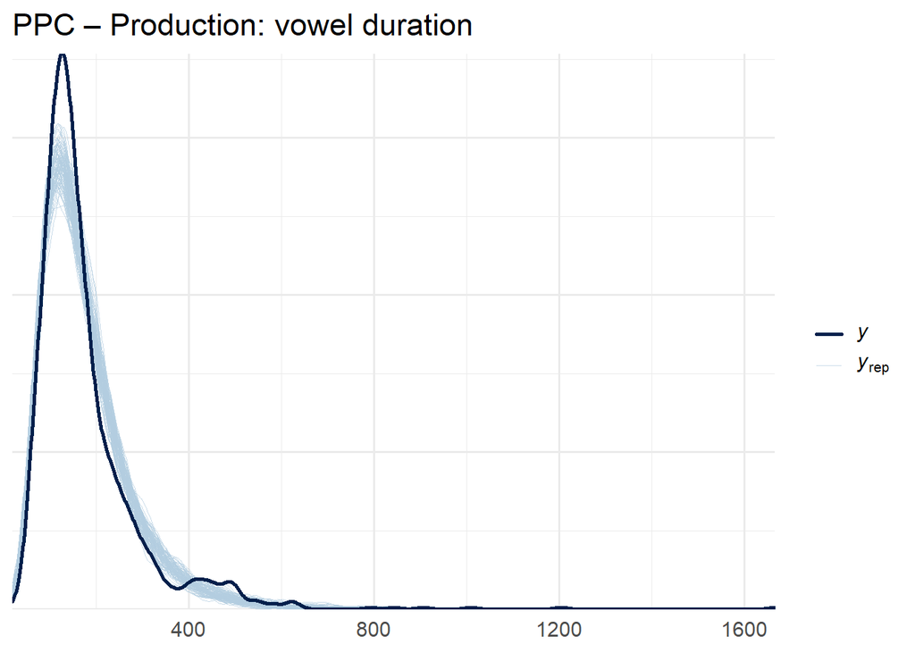

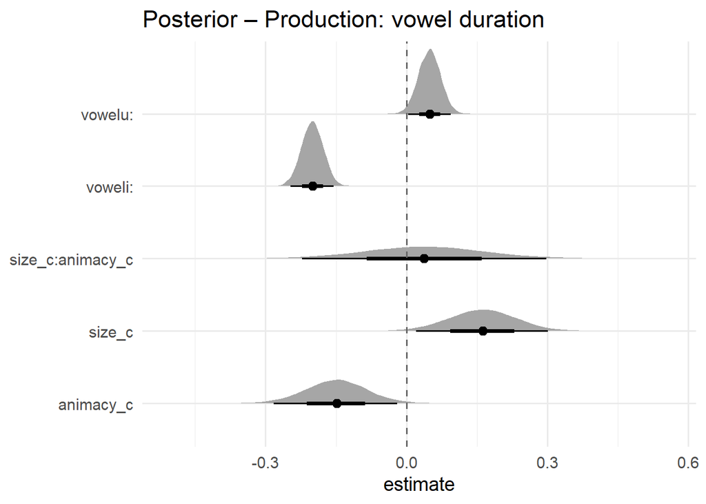

```
##
## ==========  Production: f0  ==========
## Summary of Posterior Distribution
##
## Parameter        | Median |         95% CI |     pd |  Rhat |   ESS
## -------------------------------------------------------------------
## (Intercept)      |   4.80 | [ 4.70,  4.90] |   100% | 1.001 |  3070
## size_c           |  -0.18 | [-0.28, -0.08] | 99.96% | 1.001 |  2830
## animacy_c        |   0.10 | [ 0.00,  0.20] | 97.64% | 1.001 |  2769
## sexw             |   0.58 | [ 0.49,  0.68] |   100% | 1.001 |  3003
## voweli:          |   0.14 | [ 0.11,  0.17] |   100% | 1.000 | 15931
## vowelu:          |   0.21 | [ 0.18,  0.24] |   100% | 1.000 | 15758
## size_c:animacy_c |  -0.11 | [-0.31,  0.08] | 87.36% | 1.001 |  2632
```

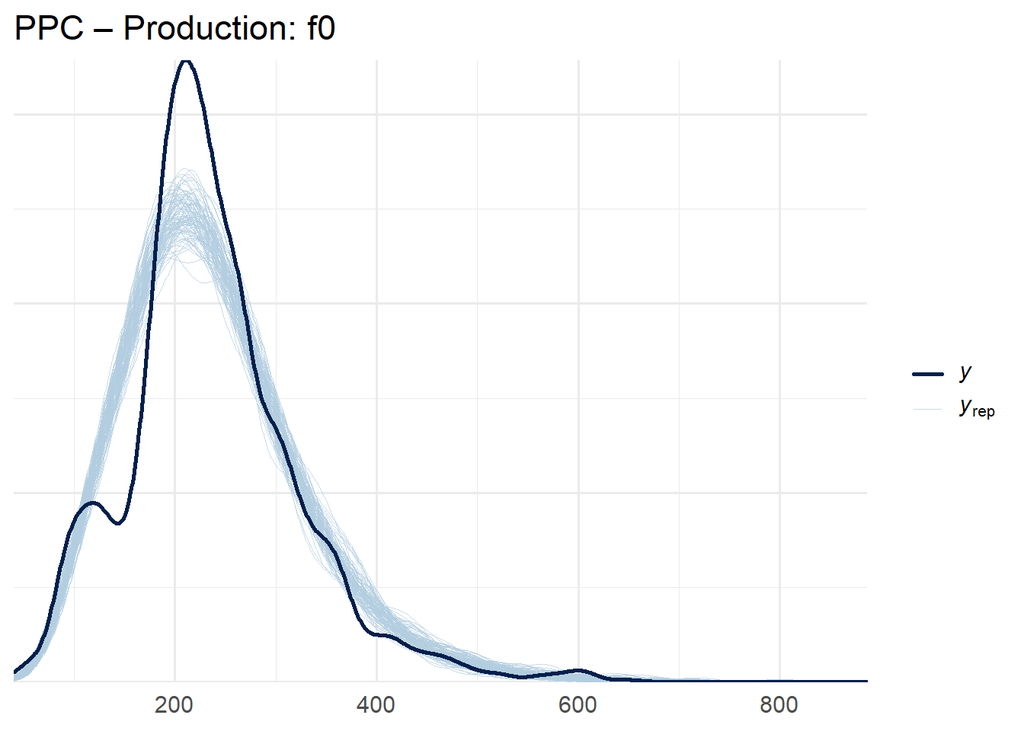

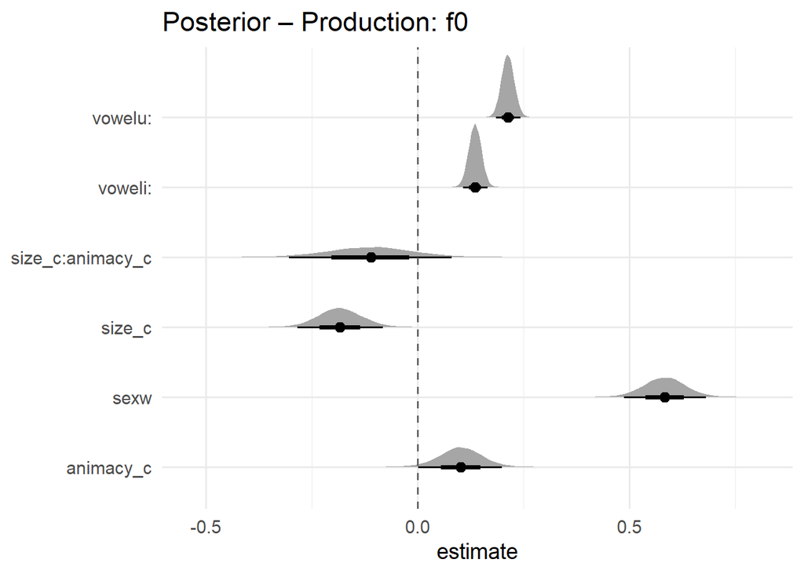

```
##
## ==========  Perception: duration → big judgment  ==========
## Summary of Posterior Distribution
##
## Parameter                     | Median |        95% CI |     pd |  Rhat |   ESS
## -------------------------------------------------------------------------------
## (Intercept)                   |  -0.08 | [-0.71, 0.55] | 60.64% | 1.001 |  2703
## vowel_dur_ms_mean_z           |   0.05 | [-0.15, 0.25] | 70.08% | 1.000 | 22708
## animacy_c                     |  -0.92 | [-2.18, 0.36] | 92.58% | 1.001 |  2940
## vowel_dur_ms_mean_z:animacy_c |   0.34 | [-0.05, 0.73] | 95.53% | 1.000 | 19473
```

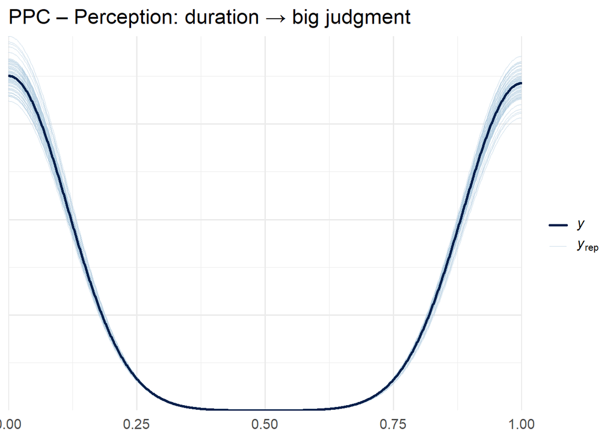

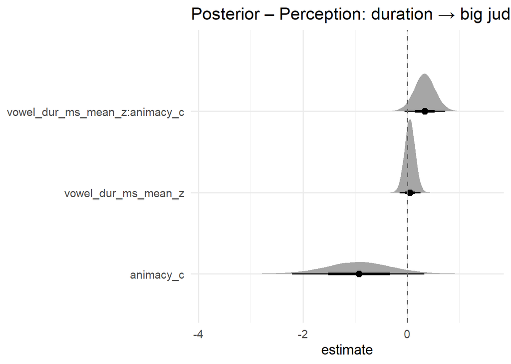

```
##
## ==========  Perception: f0 → big judgment  ==========
## Summary of Posterior Distribution
##
## Parameter           | Median |         95% CI |     pd |  Rhat |   ESS
## ----------------------------------------------------------------------
## (Intercept)         |  -0.08 | [-0.64,  0.45] | 62.46% | 1.001 |  4825
## f0_mean_z           |  -0.52 | [-0.77, -0.25] | 99.99% | 1.000 | 21278
## animacy_c           |  -0.71 | [-1.78,  0.38] | 90.71% | 1.000 |  5235
## f0_mean_z:animacy_c |  -0.28 | [-0.79,  0.22] | 86.49% | 1.000 | 27617
```

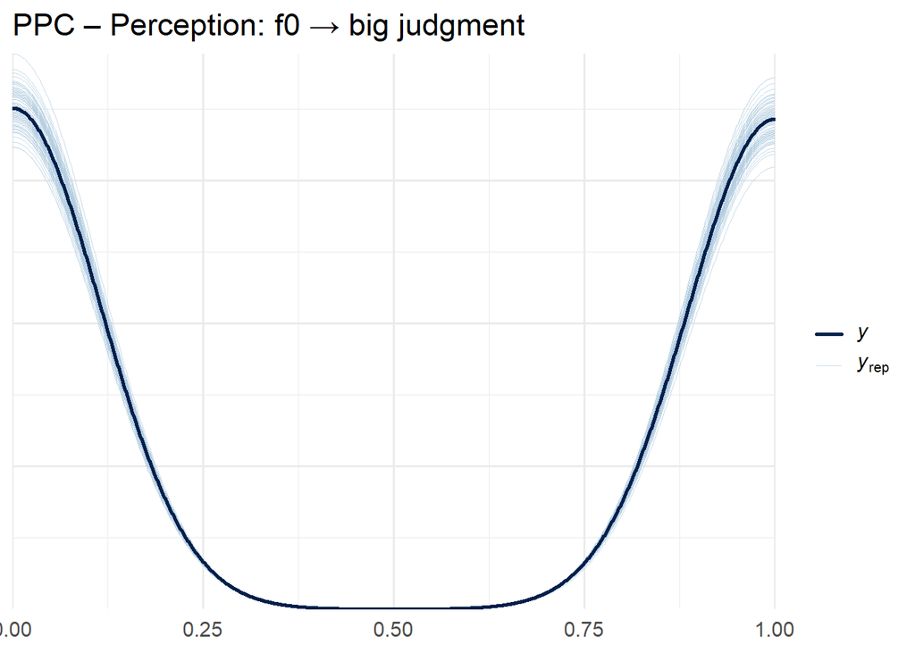

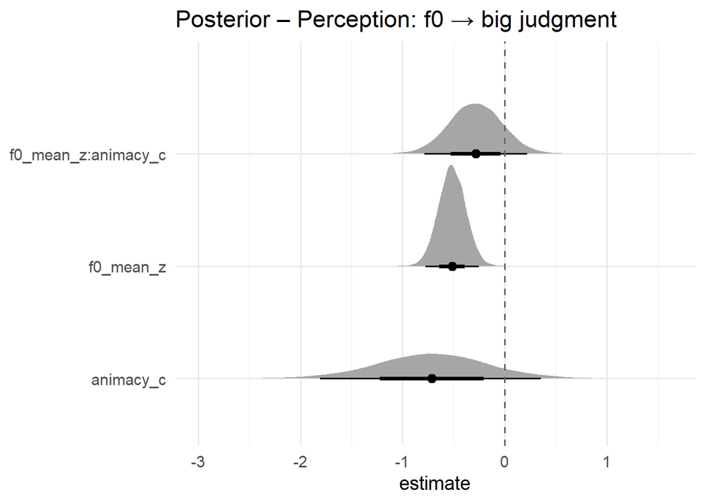

### Summary of primary findings

**Production – size effects.** Speakers produced big referents with vowels **~18% longer** than small referents (β = 0.16 on the log scale, 95% HDI [0.02, 0.30]; P(β > 0) = 0.99) and with **~17% lower f0** (β = −0.18, 95% HDI [−0.28, −0.08]; P(β < 0) = 1.00). Both predicted production effects are supported.

**Animacy as a modulator of the size effect – no evidence.** The size × animacy interaction was close to zero on both acoustic dimensions (vowel duration: β = 0.04, 95% HDI [−0.22, 0.30], P = 0.61; f0: β = −0.11, 95% HDI [−0.31, 0.08], P = 0.87). The size effect did not differ measurably between animate and inanimate referents – iconic size encoding operates the same way across both categories.

**Animacy as an independent shift in the baseline – credible in production, but see §7.8** Animacy lands on the main-effect channel rather than the interaction channel. Independent of size, animate referents were produced with vowels **~14% shorter** than inanimate referents (β = −0.15, 95% HDI [−0.28, −0.02]; P(β < 0) = 0.99) and with **~11% higher f0** (β = 0.10, 95% HDI [0.00, 0.20]; P(β > 0) = 0.98). On the perception side both animacy main effects pointed in the same direction (animate referents less likely to be judged “big”) but their credible intervals crossed zero (duration model: β = −0.92, 95% HDI [−2.18, 0.36], P = 0.93; f0 model: β = −0.71, 95% HDI [−1.78, 0.39], P = 0.91). §7.8 returns to these production animacy main effects and shows that they do not survive the addition of an item-level cuteness covariate – the animacy effect shrinks toward zero and cuteness itself does not take its place, consistent with the two predictors being too correlated in this stimulus set to identify separately.

**Reading the main-effect-without-interaction pattern.** That speakers shift their acoustic baseline by animacy *without* changing how strongly they encode size means two things happen in parallel: (i) the size mapping is robust across the animacy distinction, and (ii) there is a separate, additive shift between speaking for animals and speaking for objects. Whether this shift reflects animacy as a feature or systematic differences between the animal and object item sets in this stimulus battery cannot be separated with the present design – §7.8 makes this concrete by adding a separately-collected per-item cuteness covariate, with the result that the animacy main effect on production becomes non-credible without cuteness itself replacing it.

## 6.7 Size effects across the four primary models

A single forest plot of the size posterior across the four primary models – the headline graphic for the size question. Positive values indicate the size-iconic direction for duration (longer for big); for f0 the prediction is **negative** (lower for big), so a posterior concentrated below zero supports the frequency-code prediction (Ohala 1984; Winter 2025).

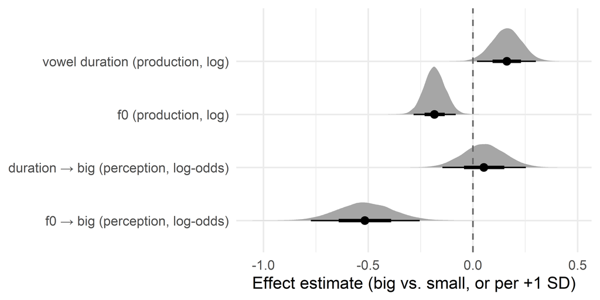

**Figure 11.** Size effect across the four primary models. Filled intervals: 66% and 95% HDI; dashed line at zero.

```r
extract_term <- function(model, term, name) {
  as_draws_df(model) |>
    transmute(model = name, value = .data[[paste0("b_", term)]])
}

main_effects <- bind_rows(
  extract_term(m_vdur,     "size_c",                "vowel duration (production, log)"),
  extract_term(m_f0,       "size_c",                "f0 (production, log)"),
  extract_term(m_perc_dur, "vowel_dur_ms_mean_z",   "duration → big (perception, log-odds)"),
  extract_term(m_perc_f0,  "f0_mean_z",             "f0 → big (perception, log-odds)")
) |>
  mutate(model = factor(model, levels = unique(model)))
ggplot(main_effects, aes(x = value, y = fct_rev(model))) +
  stat_halfeye(.width = c(0.66, 0.95)) +
  geom_vline(xintercept = 0, linetype = 2, colour = "grey40") +
  labs(x = "Effect estimate (big vs. small, or per +1 SD)",
       y = NULL#,
       #title = "Size effects in production and perception",
       #subtitle = "Predicted direction: positive for duration; negative for f0"
       )
```

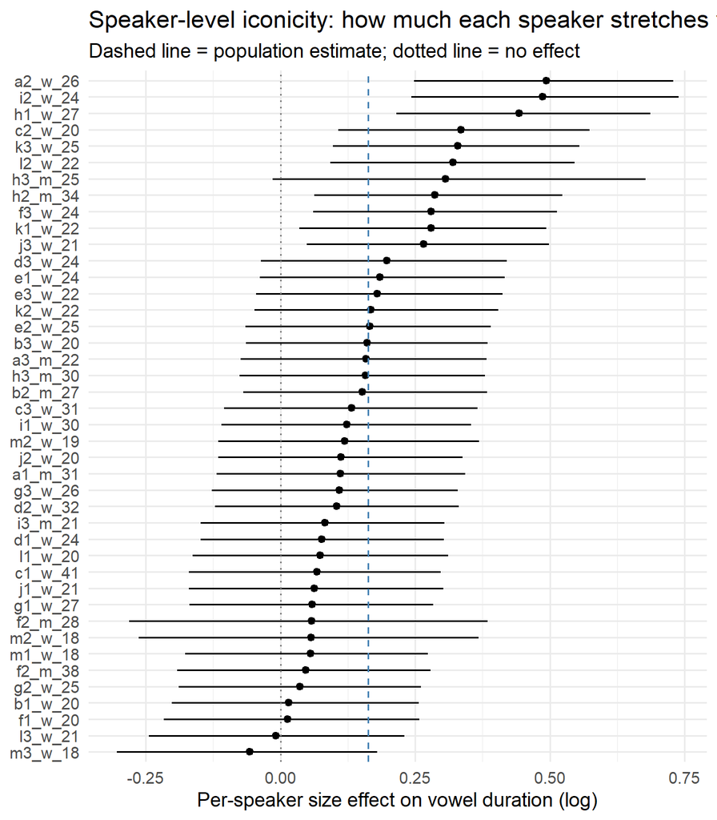

**Figure 12.** Per-speaker estimated size effect on vowel duration (log scale), sorted by magnitude. Dashed line = population-level estimate.

```r
speaker_slopes_vdur <- m_vdur |>
  spread_draws(b_size_c, r_speaker[speaker, term]) |>
  filter(term == "size_c") |>
  mutate(slope = b_size_c + r_speaker) |>
  group_by(speaker) |>
  median_hdi(slope, .width = 0.95) |>
  ungroup() |>
  mutate(speaker = fct_reorder(factor(speaker), slope))

pop_med <- median(as_draws_df(m_vdur)$b_size_c)

ggplot(speaker_slopes_vdur, aes(y = speaker, x = slope, xmin = .lower, xmax = .upper)) +
  geom_pointrange(size = 0.3) +
  geom_vline(xintercept = 0,       linetype = 3, colour = "grey50") +
  geom_vline(xintercept = pop_med, linetype = 2, colour = "steelblue") +
  labs(x = "Per-speaker size effect on vowel duration (log)",
       y = NULL,
       title = "Speaker-level iconicity: how much each speaker stretches vowels for big",
       subtitle = "Dashed line = population estimate; dotted line = no effect")
```

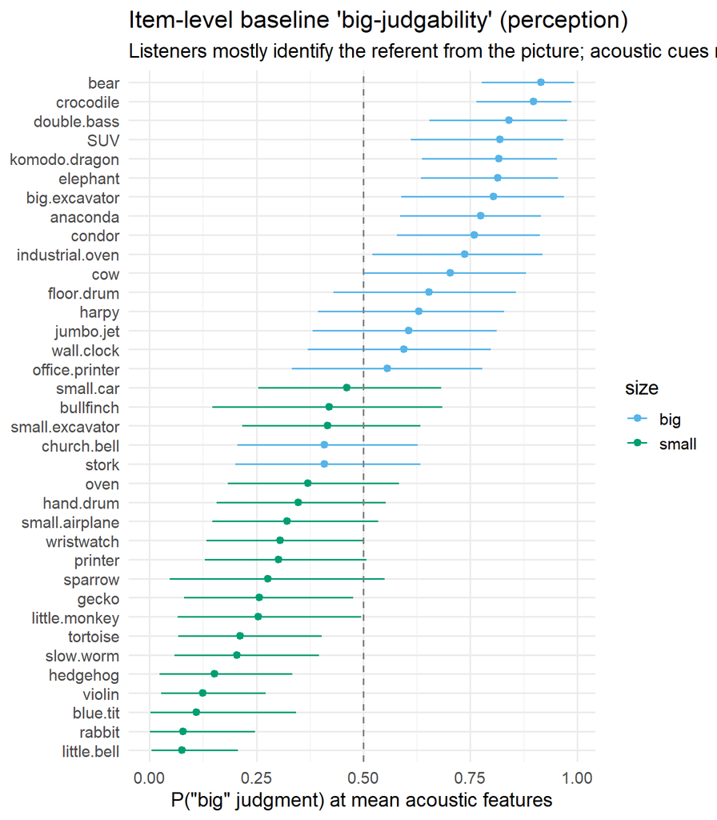

**Figure 13.** Posterior probability of ‘big’ judgment for each item (m_perc_f0), holding f0 at its mean. Items are coloured by their portrayed size.

```r
item_size <- perc |> distinct(item_english, size)

item_probs <- m_perc_f0 |>
  spread_draws(b_Intercept, r_item_english[item_english, term]) |>
  filter(term == "Intercept") |>
  mutate(p_big = plogis(b_Intercept + r_item_english)) |>
  group_by(item_english) |>
  median_hdi(p_big, .width = 0.95) |>
  ungroup() |>
  left_join(item_size, by = "item_english") |>
  mutate(item_english = fct_reorder(item_english, p_big))

ggplot(item_probs, aes(y = item_english, x = p_big,
                       xmin = .lower, xmax = .upper, colour = size)) +
  geom_pointrange(size = 0.3) +
  geom_vline(xintercept = 0.5, linetype = 2, colour = "grey50") +
  scale_colour_manual(values = colorBlindBlack8[c(3, 4)]) +
  labs(x = "P(\"big\" judgment) at mean acoustic features",
       y = NULL,
       title = "Item-level baseline 'big-judgability' (perception)",
       subtitle = "Listeners mostly identify the referent from the picture; acoustic cues modulate on top of this")
```

## 6.8 Animacy effects across the four primary models

Each model contains two animacy-relevant terms: the **interaction** `size_c × animacy_c` (does the size effect differ between animate and inanimate referents?) and the **main effect** of `animacy_c` (does animacy shift the outcome independent of size?). A finding can land on either, both, or neither. Reporting both keeps us honest about what the data say, since the animacy expectation was open as to which channel would carry it.

```r
interactions_df <- bind_rows(
  extract_term(m_vdur,     "size_c:animacy_c",                  "vowel duration (production)"),
  extract_term(m_f0,       "size_c:animacy_c",                  "f0 (production)"),
  extract_term(m_perc_dur, "vowel_dur_ms_mean_z:animacy_c",     "duration (perception)"),
  extract_term(m_perc_f0,  "f0_mean_z:animacy_c",               "f0 (perception)")
) |>
  mutate(model = factor(model, levels = unique(model)))
```

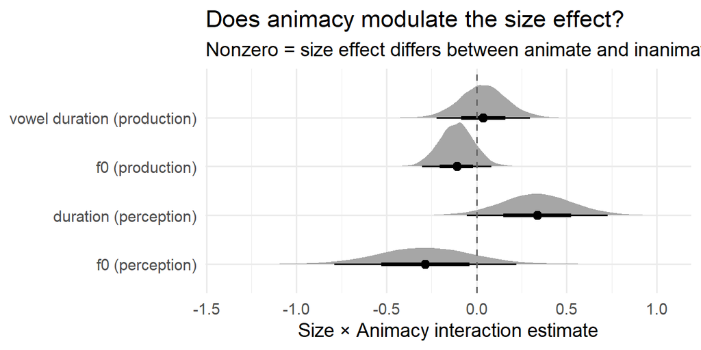

**Figure 14.** Size × animacy interaction across the four primary models.

```r
ggplot(interactions_df, aes(x = value, y = fct_rev(model))) +
  stat_halfeye(.width = c(0.66, 0.95)) +
  geom_vline(xintercept = 0, linetype = 2, colour = "grey40") +
  labs(x = "Size × Animacy interaction estimate",
       y = NULL,
       title = "Does animacy modulate the size effect?",
       subtitle = "Nonzero = size effect differs between animate and inanimate referents")
```

```r
animacy_main_df <- bind_rows(
  extract_term(m_vdur,     "animacy_c", "vowel duration (production)"),
  extract_term(m_f0,       "animacy_c", "f0 (production)"),
  extract_term(m_perc_dur, "animacy_c", "duration model (perception)"),
  extract_term(m_perc_f0,  "animacy_c", "f0 model (perception)")
) |>
  mutate(model = factor(model, levels = unique(model)))
```

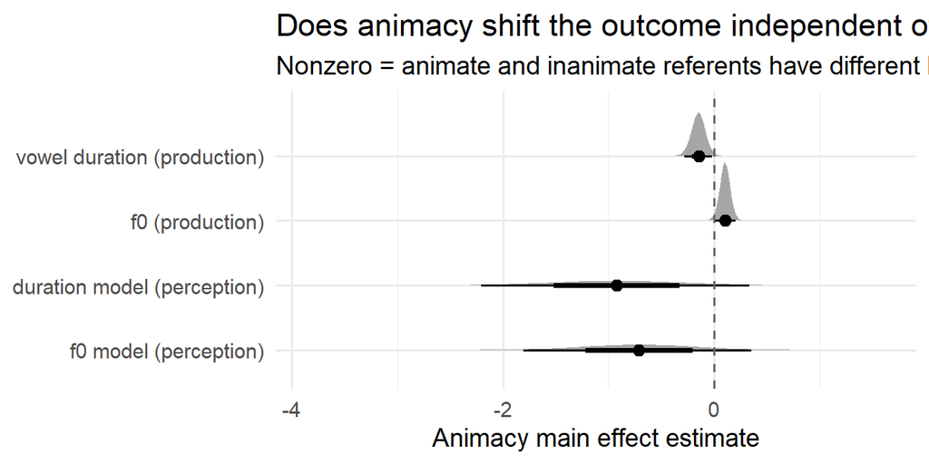

**Figure 15.** Animacy main effect across the four primary models.

```r
ggplot(animacy_main_df, aes(x = value, y = fct_rev(model))) +
  stat_halfeye(.width = c(0.66, 0.95)) +
  geom_vline(xintercept = 0, linetype = 2, colour = "grey40") +
  labs(x = "Animacy main effect estimate",
       y = NULL,
       title = "Does animacy shift the outcome independent of size?",
       subtitle = "Nonzero = animate and inanimate referents have different baselines")
```

```r
# Predicted outcome at the four corners of size × animacy.
# Random effects are integrated out (re_formula = NA): we get population-level
# predictions, which is what makes the parallel-vs-tilted geometry clean.
plot_size_by_animacy <- function(model, y_label, title_text,
                                 vowel_ref = "a:", phoneme_ref = "C", sex_ref = "m") {
  # Use the model's actual data columns to decide which covariates to supply.
  # all.vars(formula(model)) doesn't reliably traverse a brmsformula tree.
  model_vars <- names(model$data)

  newd <- expand_grid(
    size_c    = c(-0.5, 0.5),
    animacy_c = c(-0.5, 0.5)
  )
  if ("vowel"   %in% model_vars) newd$vowel   <- vowel_ref
  if ("phoneme" %in% model_vars) newd$phoneme <- phoneme_ref
  if ("sex"     %in% model_vars) newd$sex     <- sex_ref

  newd |>
    add_epred_draws(model, re_formula = NA) |>
    mutate(
      size    = factor(if_else(size_c < 0, "small", "big"), levels = c("small", "big")),
      animacy = if_else(animacy_c < 0, "inanimate", "animate")
    ) |>
    ggplot(aes(x = size, y = .epred, colour = animacy, group = animacy)) +
    stat_pointinterval(.width = c(0.66, 0.95),
                       position = position_dodge(width = 0.2)) +
    stat_summary(fun = median, geom = "line",
                 position = position_dodge(width = 0.2),
                 linewidth = 0.8) +
    scale_colour_manual(values = colorBlindBlack8[c(3, 4)]) +
    labs(x = NULL, y = y_label, colour = "Animacy", title = title_text)
}
```

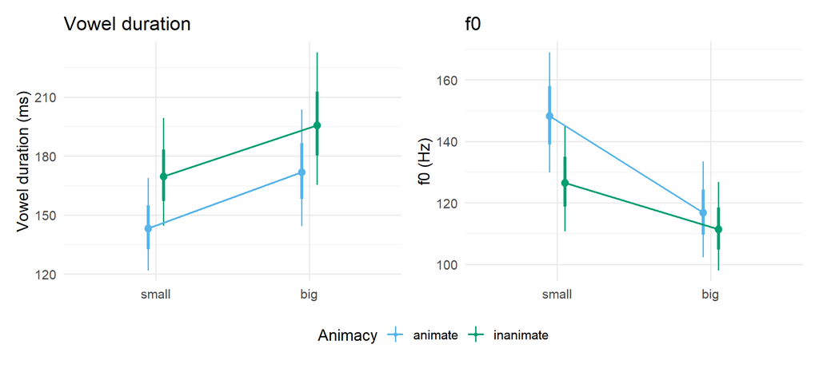

**Figure 16.** Population-level predicted outcomes at the four cells of size × animacy. Parallel lines indicate an animacy main effect without modulation; tilted (non-parallel) lines would indicate that the size effect itself differs between animate and inanimate referents.

```r
p1 <- plot_size_by_animacy(m_vdur, "Vowel duration (ms)", "Vowel duration")
p2 <- plot_size_by_animacy(m_f0,   "f0 (Hz)",             "f0")

(p1 + p2) +
  plot_layout(guides = "collect") &
  theme(legend.position = "bottom")
```

The f0 panel tells a slightly different story. The lines aren’t quite parallel – blue (animate) starts higher at `small` (~**148** Hz) and converges with green (inanimate) at `big` (~**115** Hz). That mild convergence is exactly the soft hint of a non-zero interaction we saw in the numbers (β = −0.11, 95% **HDI** [−0.31, 0.08]; P(β < 0) = 0.87). The CrI brushes zero so it’s not a claim, but the geometry makes the hint visible: animate referents seem to do more iconic “lowering” than inanimate ones do.

# 7. Exploratory analyses

## 7.1 Templates

Three reusable fitters. `fit_prod_vocalic` mirrors the production frame in §6.3 (size × animacy interaction, sex covariate, vowel fixed effect, by-speaker random intercept and slope, by-item random intercept). `fit_prod_fric` is the same idea for the fricative tables, with `phoneme` replacing `sex + vowel` as the covariate. `fit_perc_bin` mirrors §6.4–6.5 for a binary perception outcome on a single z-scored acoustic predictor.

```r
# Production: continuous vocalic outcome
fit_prod_vocalic <- function(outcome, family = gaussian(), data = vowel_long) {
  formula <- bf(as.formula(paste(
    outcome, "~ size_c * animacy_c + sex + vowel +",
    "(1 + size_c | speaker) + (1 | item_english)"
  )))
  d <- data |> filter(!is.na(.data[[outcome]]))
  fit_brm(formula, data = d, family = family,
          file = paste0(models, "m_prod_", outcome))
}

# Production: continuous fricative outcome
fit_prod_fric <- function(outcome, family = gaussian(), data = fric_long) {
  formula <- bf(as.formula(paste(
    outcome, "~ size_c * animacy_c + phoneme +",
    "(1 + size_c | speaker) + (1 | item_english)"
  )))
  d <- data |> filter(!is.na(.data[[outcome]]))
  fit_brm(formula, data = d, family = family,
          file = paste0(models, "m_prod_", outcome))
}

# Perception: binary outcome on a single z-scored predictor
fit_perc_bin <- function(outcome, predictor_z, data = perc) {
  formula <- bf(as.formula(paste(
    outcome, "~", predictor_z, "* animacy_c +",
    "(1 | listener) + (1 | speaker) + (1 | item_english)"
  )))
  d <- data |> filter(!is.na(.data[[predictor_z]]))
  fit_brm(formula, data = d, family = bernoulli(),
          file = paste0(models, "m_perc_", outcome, "_", predictor_z))
}
```

## 7.2 Other vocalic features (F1, F2, CPP, H1–H2)

We model the same vocalic frame as in §6 but swap the outcome. F1 and F2 are the first two formants (correlates of vowel quality). F1 in particular tracks both mouth opening and tongue height: lower F1 reflects a less open mouth or a higher tongue position, and the two articulators trade off but not one-to-one. CPP (cepstral peak prominence) and H1–H2 (the level difference between the first and second harmonics) index voice quality: higher CPP indicates a more periodic, modal voice; H1–H2 is typically larger in breathier voice. F1 and F2 are modelled lognormally because they are bounded below at zero with a right tail; CPP and H1–H2 are modelled with the default Gaussian since they are centred dB-scale quantities.

The formant question is worth flagging up front. Ćwiek and Fuchs (2025) examined whether object size modulates lip opening or formant dispersion in a paradigm where participants “shot” at cans of different sizes mounted on a wall while saying *piff* or *paff*, and reported no detectable size effect on either measure: vowel identity dominated the articulatory and acoustic outcomes. Our paradigm differs (imitative production of the same carrier sentence with free choice of vocalic realisation rather than a fixed two-vowel target, and animate referents alongside inanimate ones), so any divergence between the two studies is more usefully read as a difference in scope than as a contradiction. We examine F1 and F2 here in that spirit.

```r
m_F1   <- fit_prod_vocalic("F1",   family = lognormal())
```

```
## [fit_brm] Cache exists at 'm_prod_F1.rds' – brms will reuse it if formula/data/prior match.
```

```r
m_F2   <- fit_prod_vocalic("F2",   family = lognormal())
```

```
## [fit_brm] Cache exists at 'm_prod_F2.rds' – brms will reuse it if formula/data/prior match.
```

```r
m_CPP  <- fit_prod_vocalic("CPP")          # gaussian (default)
```

```
## [fit_brm] Cache exists at 'm_prod_CPP.rds' – brms will reuse it if formula/data/prior match.
```

```r
m_H1H2 <- fit_prod_vocalic("H1H2")         # gaussian (default)
```

```
## [fit_brm] Cache exists at 'm_prod_H1H2.rds' – brms will reuse it if formula/data/prior match.
```

```r
summary(m_F1)
```

```
##  Family: lognormal
##   Links: mu = identity
## Formula: F1 ~ size_c * animacy_c + sex + vowel + (1 + size_c | speaker) + (1 | item_english)
##    Data: data (Number of observations: 1361)
##   Draws: 4 chains, each with iter = 8000; warmup = 4000; thin = 1;
##          total post-warmup draws = 16000
##
## Multilevel Hyperparameters:
## ~item_english (Number of levels: 36)
##               Estimate Est.Error l-95% CI u-95% CI Rhat Bulk_ESS Tail_ESS
## sd(Intercept)     0.02      0.01     0.00     0.05 1.00     4979     7741
##
## ~speaker (Number of levels: 42)
##                       Estimate Est.Error l-95% CI u-95% CI Rhat Bulk_ESS
## sd(Intercept)             0.07      0.01     0.05     0.10 1.00     6335
## sd(size_c)                0.03      0.02     0.00     0.08 1.00     5040
## cor(Intercept,size_c)     0.07      0.49    -0.90     0.93 1.00    15742
##                       Tail_ESS
## sd(Intercept)            10867
## sd(size_c)                7683
## cor(Intercept,size_c)     9471
##
## Regression Coefficients:
##                  Estimate Est.Error l-95% CI u-95% CI Rhat Bulk_ESS Tail_ESS
## Intercept            6.67      0.03     6.60     6.74 1.00    10619    11173
## size_c              -0.06      0.02    -0.10    -0.03 1.00    23345    12366
## animacy_c            0.06      0.02     0.02     0.09 1.00    26673    12478
## sexw                 0.05      0.04    -0.03     0.12 1.00     9787    11124
## voweli:             -0.94      0.02    -0.97    -0.90 1.00    25384    12777
## vowelu:             -0.71      0.02    -0.74    -0.67 1.00    26187    12846
## size_c:animacy_c    -0.01      0.03    -0.08     0.05 1.00    25299    12702
##
## Further Distributional Parameters:
##       Estimate Est.Error l-95% CI u-95% CI Rhat Bulk_ESS Tail_ESS
## sigma     0.28      0.01     0.27     0.29 1.00    27652    11611
##
## Draws were sampled using sample(hmc). For each parameter, Bulk_ESS
## and Tail_ESS are effective sample size measures, and Rhat is the potential
## scale reduction factor on split chains (at convergence, Rhat = 1).
```

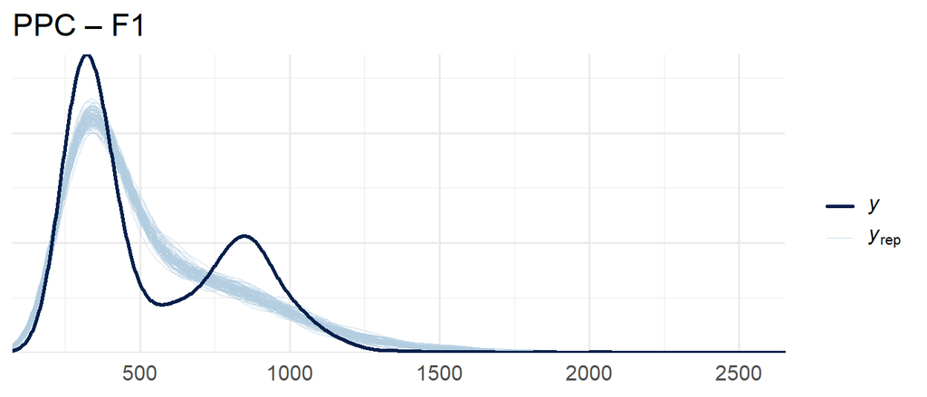

**Figure 17.** Posterior predictive check for F1 (lognormal).

```r
pp_check(m_F1, ndraws = 100) + ggtitle("PPC – F1")
```

Bimodal because of different vowels.

```r
summary(m_F2)
```

```
##  Family: lognormal
##   Links: mu = identity
## Formula: F2 ~ size_c * animacy_c + sex + vowel + (1 + size_c | speaker) + (1 | item_english)
##    Data: data (Number of observations: 1361)
##   Draws: 4 chains, each with iter = 8000; warmup = 4000; thin = 1;
##          total post-warmup draws = 16000
##
## Multilevel Hyperparameters:
## ~item_english (Number of levels: 36)
##               Estimate Est.Error l-95% CI u-95% CI Rhat Bulk_ESS Tail_ESS
## sd(Intercept)     0.03      0.01     0.00     0.05 1.00     4114     5872
##
## ~speaker (Number of levels: 42)
##                       Estimate Est.Error l-95% CI u-95% CI Rhat Bulk_ESS
## sd(Intercept)             0.04      0.01     0.01     0.07 1.00     4532
## sd(size_c)                0.02      0.02     0.00     0.07 1.00     7715
## cor(Intercept,size_c)     0.19      0.54    -0.89     0.97 1.00    15047
##                       Tail_ESS
## sd(Intercept)             3736
## sd(size_c)                8715
## cor(Intercept,size_c)    10691
##
## Regression Coefficients:
##                  Estimate Est.Error l-95% CI u-95% CI Rhat Bulk_ESS Tail_ESS
## Intercept            7.32      0.03     7.26     7.37 1.00    16482    13257
## size_c              -0.01      0.02    -0.04     0.03 1.00    20552    12991
## animacy_c            0.02      0.02    -0.01     0.06 1.00    21144    11955
## sexw                -0.02      0.03    -0.08     0.03 1.00    15380    12256
## voweli:              0.37      0.02     0.34     0.41 1.00    23570    12528
## vowelu:             -0.01      0.02    -0.05     0.03 1.00    24066    12701
## size_c:animacy_c     0.02      0.04    -0.06     0.09 1.00    20867    12752
##
## Further Distributional Parameters:
##       Estimate Est.Error l-95% CI u-95% CI Rhat Bulk_ESS Tail_ESS
## sigma     0.29      0.01     0.28     0.30 1.00    26337    11017
##
## Draws were sampled using sample(hmc). For each parameter, Bulk_ESS
## and Tail_ESS are effective sample size measures, and Rhat is the potential
## scale reduction factor on split chains (at convergence, Rhat = 1).
```

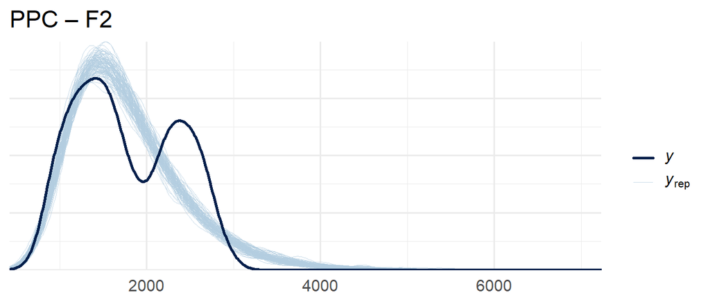

**Figure 18.** Posterior predictive check for F2 (lognormal).

```r
pp_check(m_F2, ndraws = 100) + ggtitle("PPC – F2")
```

Bimodal because of different vowels.

```r
summary(m_CPP)
```

```
##  Family: gaussian
##   Links: mu = identity
## Formula: CPP ~ size_c * animacy_c + sex + vowel + (1 + size_c | speaker) + (1 | item_english)
##    Data: data (Number of observations: 1361)
##   Draws: 4 chains, each with iter = 8000; warmup = 4000; thin = 1;
##          total post-warmup draws = 16000
##
## Multilevel Hyperparameters:
## ~item_english (Number of levels: 36)
##               Estimate Est.Error l-95% CI u-95% CI Rhat Bulk_ESS Tail_ESS
## sd(Intercept)     0.84      0.31     0.17     1.42 1.00     3742     3143
##
## ~speaker (Number of levels: 42)
##                       Estimate Est.Error l-95% CI u-95% CI Rhat Bulk_ESS
## sd(Intercept)             2.26      0.33     1.69     2.98 1.00     5935
## sd(size_c)                1.45      0.64     0.16     2.66 1.00     3100
## cor(Intercept,size_c)     0.22      0.33    -0.50     0.85 1.00    10661
##                       Tail_ESS
## sd(Intercept)             9993
## sd(size_c)                4197
## cor(Intercept,size_c)     6396
##
## Regression Coefficients:
##                  Estimate Est.Error l-95% CI u-95% CI Rhat Bulk_ESS Tail_ESS
## Intercept           19.86      0.94    18.03    21.71 1.00     8639    10624
## size_c               1.10      0.51     0.11     2.11 1.00    15993    13217
## animacy_c           -1.57      0.44    -2.44    -0.69 1.00    17874    11983
## sexw                -0.78      0.99    -2.74     1.15 1.00     7647     9585
## voweli:             -5.53      0.40    -6.33    -4.74 1.00    28389    13459
## vowelu:             -6.73      0.40    -7.52    -5.95 1.00    26453    13316
## size_c:animacy_c     0.14      0.88    -1.60     1.86 1.00    17652    12683
##
## Further Distributional Parameters:
##       Estimate Est.Error l-95% CI u-95% CI Rhat Bulk_ESS Tail_ESS
## sigma     6.06      0.12     5.83     6.30 1.00    21187    11560
##
## Draws were sampled using sample(hmc). For each parameter, Bulk_ESS
## and Tail_ESS are effective sample size measures, and Rhat is the potential
## scale reduction factor on split chains (at convergence, Rhat = 1).
```

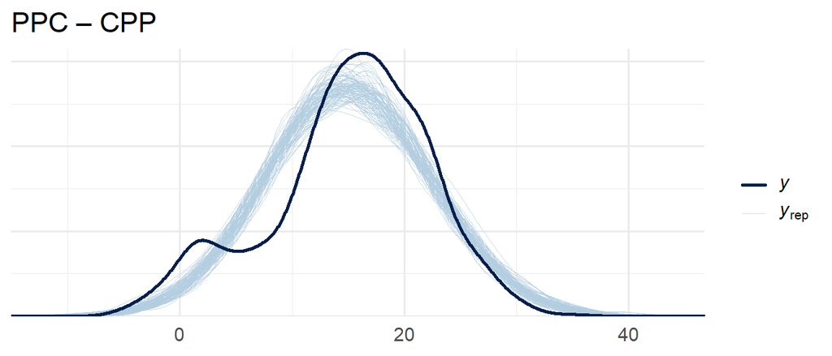

**Figure 19.** Posterior predictive check for CPP (Gaussian).

```r
pp_check(m_CPP, ndraws = 100) + ggtitle("PPC – CPP")
```

```r
summary(m_H1H2)
```

```
##  Family: gaussian
##   Links: mu = identity
## Formula: H1H2 ~ size_c * animacy_c + sex + vowel + (1 + size_c | speaker) + (1 | item_english)
##    Data: data (Number of observations: 1351)
##   Draws: 4 chains, each with iter = 8000; warmup = 4000; thin = 1;
##          total post-warmup draws = 16000
##
## Multilevel Hyperparameters:
## ~item_english (Number of levels: 36)
##               Estimate Est.Error l-95% CI u-95% CI Rhat Bulk_ESS Tail_ESS
## sd(Intercept)     0.82      0.39     0.08     1.58 1.00     3677     4451
##
## ~speaker (Number of levels: 42)
##                       Estimate Est.Error l-95% CI u-95% CI Rhat Bulk_ESS
## sd(Intercept)             1.91      0.34     1.31     2.64 1.00     6541
## sd(size_c)                1.24      0.66     0.09     2.58 1.00     4931
## cor(Intercept,size_c)     0.46      0.38    -0.49     0.97 1.00    13357
##                       Tail_ESS
## sd(Intercept)             9286
## sd(size_c)                6204
## cor(Intercept,size_c)    10013
##
## Regression Coefficients:
##                  Estimate Est.Error l-95% CI u-95% CI Rhat Bulk_ESS Tail_ESS
## Intercept            3.33      0.92     1.56     5.12 1.00    12640    12490
## size_c              -1.21      0.56    -2.31    -0.11 1.00    17666    12727
## animacy_c           -0.04      0.51    -1.05     0.98 1.00    21755    12437
## sexw                 2.42      0.94     0.60     4.27 1.00    11592    11777
## voweli:              4.20      0.51     3.19     5.18 1.00    25835    12796
## vowelu:              0.85      0.51    -0.14     1.84 1.00    26328    12486
## size_c:animacy_c    -0.33      1.02    -2.32     1.70 1.00    19554    11287
##
## Further Distributional Parameters:
##       Estimate Est.Error l-95% CI u-95% CI Rhat Bulk_ESS Tail_ESS
## sigma     7.64      0.15     7.36     7.95 1.00    23637    11188
##
## Draws were sampled using sample(hmc). For each parameter, Bulk_ESS
## and Tail_ESS are effective sample size measures, and Rhat is the potential
## scale reduction factor on split chains (at convergence, Rhat = 1).
```

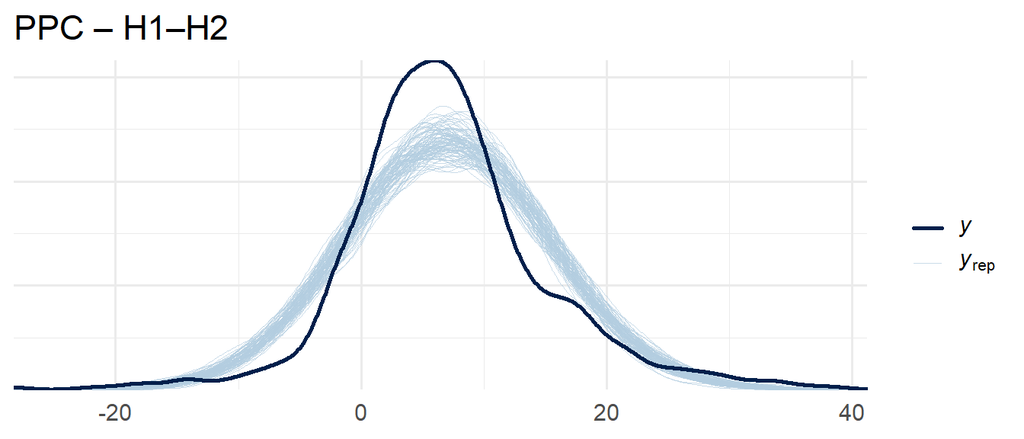

**Figure 20.** Posterior predictive check for H1–H2 (Gaussian).

```r
pp_check(m_H1H2, ndraws = 100) + ggtitle("PPC – H1–H2")
```

## 7.3 Fricative features (production)

Fricative spectral cues are routinely linked to perceived size and to the geometry of the vocal tract (Jongman, Wayland, and Wong 2000; Al-Tamimi 2022). The four features we model here are fricative duration (ms), fricative SPL (a dB-scale intensity measure on the whole fricative segment), peak spectral frequency (Hz), and centre of gravity (Hz). Duration is lognormal-distributed; the other three are kept on their native scales with a Gaussian likelihood (taking the log of frequency values tends to overshoot the actual right-skew).

```r
m_fdur  <- fit_prod_fric("fric_dur_ms",  family = lognormal())
```

```
## [fit_brm] Cache exists at 'm_prod_fric_dur_ms.rds' – brms will reuse it if formula/data/prior match.
```

```r
m_fSPL  <- fit_prod_fric("fric_SPL_dB")              # gaussian
```

```
## [fit_brm] Cache exists at 'm_prod_fric_SPL_dB.rds' – brms will reuse it if formula/data/prior match.
```

```r
m_fpeak <- fit_prod_fric("fric_peak_Hz")             # gaussian (log overshoots)
```

```
## [fit_brm] Cache exists at 'm_prod_fric_peak_Hz.rds' – brms will reuse it if formula/data/prior match.
```

```r
m_fCoG  <- fit_prod_fric("fric_CoG_Hz")              # gaussian (log overshoots)
```

```
## [fit_brm] Cache exists at 'm_prod_fric_CoG_Hz.rds' – brms will reuse it if formula/data/prior match.
```

```r
summary(m_fdur)
```

```
##  Family: lognormal
##   Links: mu = identity
## Formula: fric_dur_ms ~ size_c * animacy_c + phoneme + (1 + size_c | speaker) + (1 | item_english)
##    Data: data (Number of observations: 2471)
##   Draws: 4 chains, each with iter = 8000; warmup = 4000; thin = 1;
##          total post-warmup draws = 16000
##
## Multilevel Hyperparameters:
## ~item_english (Number of levels: 36)
##               Estimate Est.Error l-95% CI u-95% CI Rhat Bulk_ESS Tail_ESS
## sd(Intercept)     0.15      0.02     0.12     0.21 1.00     5131     8419
##
## ~speaker (Number of levels: 42)
##                       Estimate Est.Error l-95% CI u-95% CI Rhat Bulk_ESS
## sd(Intercept)             0.24      0.03     0.18     0.30 1.00     3232
## sd(size_c)                0.10      0.04     0.01     0.16 1.00     2806
## cor(Intercept,size_c)     0.02      0.30    -0.57     0.61 1.00     9949
##                       Tail_ESS
## sd(Intercept)             6190
## sd(size_c)                2031
## cor(Intercept,size_c)     5954
##
## Regression Coefficients:
##                  Estimate Est.Error l-95% CI u-95% CI Rhat Bulk_ESS Tail_ESS
## Intercept            4.03      0.05     3.93     4.12 1.00     2463     4768
## size_c               0.10      0.06    -0.02     0.21 1.00     4576     8231
## animacy_c           -0.02      0.06    -0.13     0.09 1.00     4722     7474
## phonemef             0.48      0.02     0.44     0.53 1.00    19114    12780
## phonemeS             1.13      0.04     1.05     1.22 1.00    20347    12344
## phonemez             0.38      0.02     0.33     0.42 1.00    19298    11938
## size_c:animacy_c     0.04      0.11    -0.18     0.26 1.00     4734     7323
##
## Further Distributional Parameters:
##       Estimate Est.Error l-95% CI u-95% CI Rhat Bulk_ESS Tail_ESS
## sigma     0.48      0.01     0.47     0.50 1.00    23755    12453
##
## Draws were sampled using sample(hmc). For each parameter, Bulk_ESS
## and Tail_ESS are effective sample size measures, and Rhat is the potential
## scale reduction factor on split chains (at convergence, Rhat = 1).
```

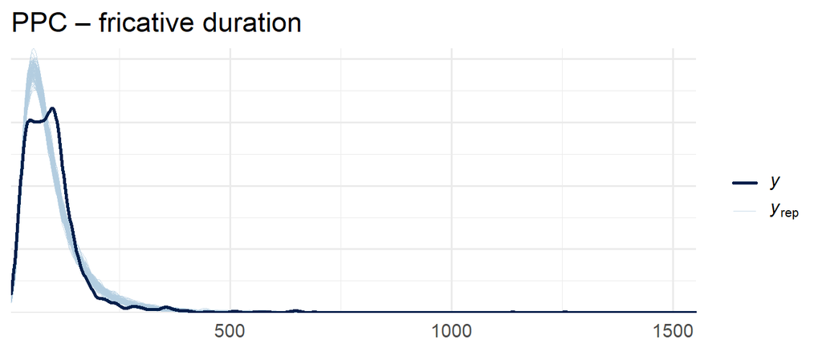

**Figure 21.** Posterior predictive check for fricative duration (lognormal).

```r
pp_check(m_fdur, ndraws = 100) + ggtitle("PPC – fricative duration")
```

```r
summary(m_fSPL)
```

```
##  Family: gaussian
##   Links: mu = identity
## Formula: fric_SPL_dB ~ size_c * animacy_c + phoneme + (1 + size_c | speaker) + (1 | item_english)
##    Data: data (Number of observations: 2471)
##   Draws: 4 chains, each with iter = 8000; warmup = 4000; thin = 1;
##          total post-warmup draws = 16000
##
## Multilevel Hyperparameters:
## ~item_english (Number of levels: 36)
##               Estimate Est.Error l-95% CI u-95% CI Rhat Bulk_ESS Tail_ESS
## sd(Intercept)     2.93      0.47     2.13     3.98 1.00     6053     8924
##
## ~speaker (Number of levels: 42)
##                       Estimate Est.Error l-95% CI u-95% CI Rhat Bulk_ESS
## sd(Intercept)             5.85      0.72     4.61     7.43 1.00     3048
## sd(size_c)                4.04      0.72     2.75     5.57 1.00     7134
## cor(Intercept,size_c)     0.01      0.19    -0.37     0.38 1.00     6882
##                       Tail_ESS
## sd(Intercept)             5465
## sd(size_c)               10569
## cor(Intercept,size_c)     9950
##
## Regression Coefficients:
##                  Estimate Est.Error l-95% CI u-95% CI Rhat Bulk_ESS Tail_ESS
## Intercept            5.89      1.09     3.73     8.03 1.00     2080     4804
## size_c               3.08      1.27     0.61     5.61 1.00     5850     7834
## animacy_c            1.29      1.09    -0.83     3.41 1.00     5586     7950
## phonemef             1.08      0.54     0.03     2.15 1.00    21839    13166
## phonemeS            32.55      0.98    30.64    34.50 1.00    22011    12585
## phonemez            10.54      0.55     9.45    11.63 1.00    20902    12803
## size_c:animacy_c     0.24      2.19    -4.06     4.57 1.00     5517     8545
##
## Further Distributional Parameters:
##       Estimate Est.Error l-95% CI u-95% CI Rhat Bulk_ESS Tail_ESS
## sigma    10.72      0.16    10.42    11.03 1.00    27654    11693
##
## Draws were sampled using sample(hmc). For each parameter, Bulk_ESS
## and Tail_ESS are effective sample size measures, and Rhat is the potential
## scale reduction factor on split chains (at convergence, Rhat = 1).
```

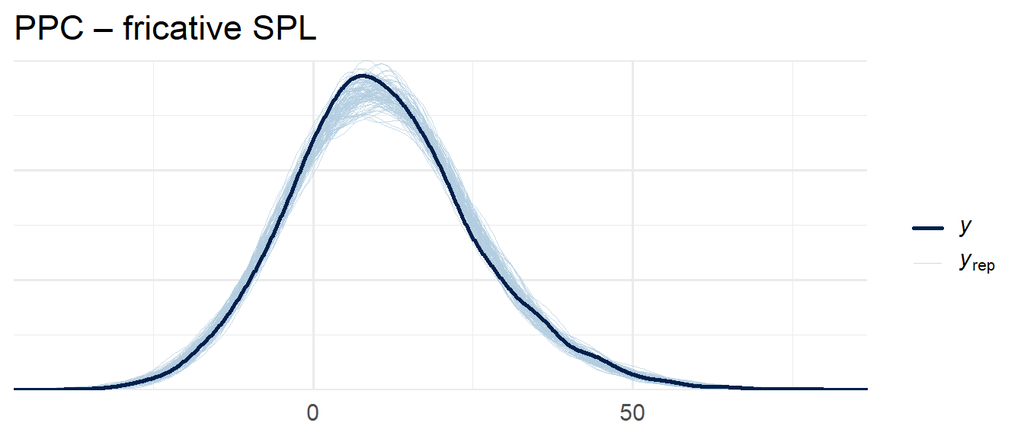

**Figure 22.** Posterior predictive check for fricative SPL (Gaussian).

```r
pp_check(m_fSPL, ndraws = 100) + ggtitle("PPC – fricative SPL")
```